# Part II - The Prosper Loan Data Analysis

## by Yahaya Yusuf Danladi

## Investigation Overview

There are three vital questions I want to answer in this presentation:

1. Does home ownership determine the loan amount a borrower can access?
2. Do recommendation letters influence the amount of loan a borrower get?
3. How does employment affects Prosper ratings?

As you can see, the Prosper loaon system does not emphasize home ownership in determining the access to loans, it is very clear that Recommendations did not play significant role in determinig the loan amount given to a borrower, since a large number of borrowers with no recommendations also get large amount of loans. Lastly, borrowers that have some source of income or employment have better Prosper ratings.

So my conclusion is that while it not not significant for borrowers the own a home or get recommendations before getting loans, it is important for them to be employent or have some source of income because this will increase their Prosper ratings.

## Dataset Overview

This data set contains 113,937 loans with 81 variables on each loan, including loan amount, borrower rate (or interest rate), current loan status, borrower income, and many others. Most of the loans originated between December 2014 and November 2015. [here](https://s3.amazonaws.com/udacity-hosted-downloads/ud651/prosperLoanData.csv) and the Dictionary definations [here](https://docs.google.com/spreadsheets/d/1gDyi_L4UvIrLTEC6Wri5nbaMmkGmLQBk-Yx3z0XDEtI/edit#gid=0).

There are 30 variable selected for this analysis with 7,6224 rows each, Primarimy, the feature of interest that we exlpored are: IsBorrowerHomeowner, EmploymentStatus, ProsperRatingNumeric, PercentFunded, LoanOriginalAmount,and Recommendations colums.

## Relationship between home ownership and the loan amount a borrower gets.

During investigation we found out that Borrowers can access any loan amount regardless they own a home or not.

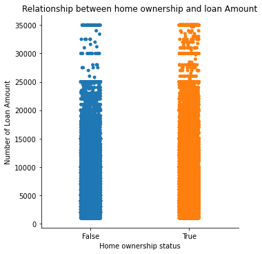

## Relationship between Recommendations and loan amount

Recommendations did not play significant role in determinig the loan amount given to a borrower, as we can see a large number of borrowers with no recommendations also get large amount of loans.

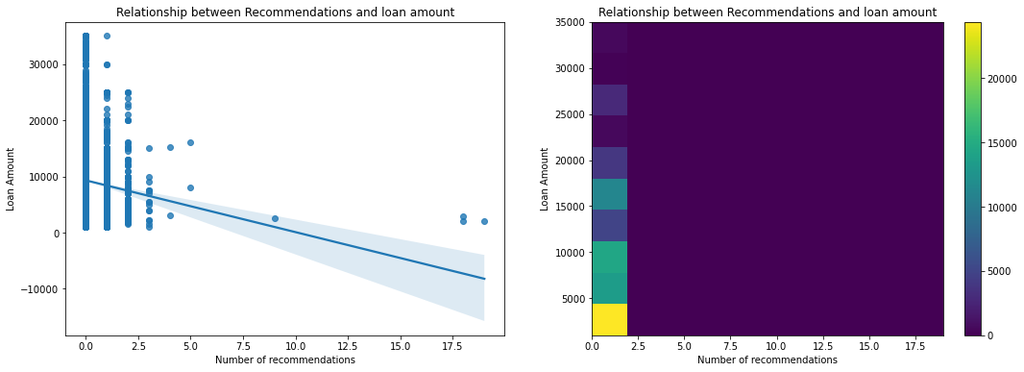

## Relationship between Employment status, homeownership and Prosper Ratings

Generally, borrowers that have some source of income or employment and are also homeowners have better Prosper ratings, hence we can say a borrowers employment status affect their rating.

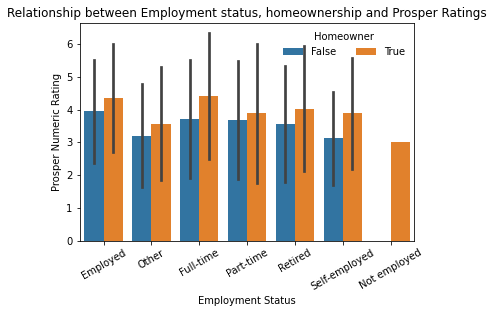